# Intro

In this project, we are analyzing various datasets to gain insights into the demographic and economic trends in US counties. The datasets used in this project are sourced from reputable organizations and provide valuable information on population, age distribution, and economic indicators. Here is an introduction to the sources of the datasets:

1. US Census Bureau: The Census Bureau is a principal agency of the US Federal Statistical System, responsible for producing data about the American people and economy. We use the Census Bureau's American Community Survey (ACS) data to obtain population and age distribution information for each county. The ACS is an ongoing survey that provides vital information on a yearly basis about the US and its people. The data is fetched using the Census API, which allows us to access the most recent and accurate information.
2. Bureau of Economic Analysis (BEA): The BEA is an agency within the US Department of Commerce that provides essential economic statistics, including GDP, personal income, and employment data. We use the BEA's Regional Economic Accounts data to obtain GDP per capita, personal income, and total employment information for each county. The data is fetched using the BEA API, ensuring that we have access to the latest and most accurate economic indicators.

By combining these datasets, we can analyze the demographic and economic trends in US counties and identify the best counties for retirees and working-age individuals. This information can be useful for individuals looking to relocate based on their age group and financial preferences, as well as for policymakers and businesses seeking to understand the demographics and economic conditions in different counties and tailor their strategies accordingly.

After merge of sources: Which counties have a high proportion of individuals who are retiring in the next 10 years, a low proportion of individuals entering the working age, and how do their GDP per capita and personal income compare to counties with a high proportion of individuals entering the working age?

1. Calculate the proportion of individuals who are retiring in the next 10 years (age 55-64) and the proportion of individuals entering the working age (age 15-24) for each county.
2. Identify counties with a high proportion of individuals retiring and a low proportion of individuals entering the working age.
3. Compare the GDP per capita and personal income of these counties to those with a high proportion of individuals entering the working age.

# Data manipulation and gathering

Population by county

The data in the fetch_population_data function is being pulled from the U.S. Census Bureau's API. This API provides access to various demographic and population-related data for the United States. In this specific function, it is fetching population data for counties in the year 2019. The data includes county names, populations, state codes, and county codes.

```python
import requests
import pandas as pd
from io import StringIO
```

```python
fips_df = pd.read_csv('fipscode.csv', names=['FIPS code', 'name'])
fips_df.head(5)
```

|  | FIPS code | name |
| --- | --- | --- |
| 0 | FIPS code | name |
| 1 | 1000 | Alabama |
| 2 | 1001 | Autauga County |
| 3 | 1003 | Baldwin County |
| 4 | 1005 | Barbour County |

```python
import requests
import pandas as pd
from io import StringIO
import traceback


def fetch_population_data(api_key):
    """
    Fetch population data from the Census API and return it as a DataFrame.
    Also saves the data as a CSV file.

    :param api_key: str, API key for the Census API
    :return: DataFrame, containing population data
    """
    try:
        # Fetch population data from the Census API
        url = f"https://api.census.gov/data/2019/pep/population?get=NAME,POP&for=county:*&key={api_key}"

        # Fetch population data from the Census API in JSON format
        response = requests.get(url)

        # Remove the square brackets from the response text
        response_text = response.text.replace('[', '').replace(']', '')

        # Create a DataFrame from the response text
        data = StringIO(response_text)
        df = pd.read_csv(data, header=None, names=["NAME", "POP", "state_code", "county_code"], skiprows=1)
        df.rename(columns={'NAME': 'population'}, inplace=True)

        # Reset the index of the DataFrame
        df.reset_index(inplace=True)

        # Rename the 'index' column to 'County'
        df.rename(columns={'index': 'County'}, inplace=True)

        # Split the NAME column into county and state
        df['county'] = df['County'].apply(lambda x: x.split(', ')[0])

        # Split the NAME column into county and state
        df['state'] = df['County'].apply(lambda x: x.split(', ')[1])

        # Drop the unnecessary columns
        df.drop(columns=['county_code'], inplace=True)

        # REname the columns
        df.rename(columns={'state_code': 'county_code'}, inplace=True)
        df.rename(columns={'POP': 'state_code'}, inplace=True)
        df.drop(columns=['County'], inplace=True)

        # Rearrange the columns
        df = df[['state', 'county', 'population', 'state_code', 'county_code']]

        # Save the DataFrame as a CSV file
        df.to_csv('population.csv', index=False)

        return df

    except Exception as e:
        print(f"An error occurred: {e}")
        traceback.print_exc()


api_key = "key_you_cant_see"
population_data = fetch_population_data(api_key)
print(population_data.head())
```

```
      state          county  population  state_code  county_code
0  Illinois  Fayette County       21336          17           51
1  Illinois    Logan County       28618          17          107
2  Illinois   Saline County       23491          17          165
3  Illinois     Lake County      696535          17           97
4  Illinois   Massac County       13772          17          127
```

# Join Fips and Population

```python
import pandas as pd

# Read in the population_data DataFrame from the 'population.csv' file
population_data = pd.read_csv('population.csv')
#print(population_data.head())
# Read in the fips_df DataFrame from the 'fipscode.csv' file
fips_df = pd.read_csv('fipscode.csv', names=['FIPS code', 'name'],skiprows=1)
#print(fips_df.head())

# Merge the two DataFrames on the 'county' and 'state' columns using an outer join
merged_data = pd.merge(population_data, fips_df, left_on=['county'], right_on=['name'], how='outer')
merged_data
# Find the rows that didn't merge from either DataFrame
unmerged_population_data = merged_data[merged_data['name'].isnull()]
unmerged_fips_data = merged_data[merged_data['county'].isnull()]

# Write the unmerged values to CSV files
unmerged_population_data.to_csv('unmerged_population_data.csv', index=False)
unmerged_fips_data.to_csv('unmerged_fips_data.csv', index=False)

# Drop the unnecessary columns and rows with NaN values
merged_data.drop(columns=[ 'name'], inplace=True)
merged_data.dropna(subset=['county'], inplace=True)
merged_data.rename(columns={'FIPS code': 'fips_code'}, inplace=True)
# Display the merged dataset
print(merged_data.head())
merged_data.to_csv('merged_data.csv', index=False)
```

```
      state          county  population  state_code  county_code  fips_code
0  Illinois  Fayette County     21336.0        17.0         51.0     1057.0
1  Illinois  Fayette County     21336.0        17.0         51.0    13113.0
2  Illinois  Fayette County     21336.0        17.0         51.0    17051.0
3  Illinois  Fayette County     21336.0        17.0         51.0    18041.0
4  Illinois  Fayette County     21336.0        17.0         51.0    19065.0
```

Here we join the fips code and the population so we know what county is to what state

```python
import pandas as pd
import traceback

def merge_population_and_fips(population_file, fips_file, output_csv):
    """
    Merge population data with FIPS code data and return the resulting dataset.

    Args:
        population_file (str): The file path to the population data CSV.
        fips_file (str): The file path to the FIPS code data CSV.
        output_csv (str): The file path to save the merged dataset as a CSV.

    Returns:
        pd.DataFrame: The merged dataset.

    Raises:
        Exception: If any error occurs during the process.
    """
    try:
        # Read in the population_data DataFrame from the population_file
        population_data = pd.read_csv(population_file)

        # Read in the fips_df DataFrame from the fips_file
        fips_df = pd.read_csv(fips_file, names=['FIPS code', 'name'], skiprows=1)

        # Pad the county_code column with zeros
        population_data['county_code'] = population_data['county_code'].astype(str).str.zfill(3)

        # Convert the state_code column to string
        population_data['state_code'] = population_data['state_code'].astype(str)

        # Concatenate the state_code and county_code columns to create a new fips_code column
        population_data['fips_code'] = population_data['state_code'] + population_data['county_code']

        # Convert FIPS code column in fips_df to string
        fips_df['FIPS code'] = fips_df['FIPS code'].astype(str)

        # Merge the two DataFrames on the fips_code column using an outer join
        merged_data = pd.merge(population_data, fips_df, left_on='fips_code', right_on='FIPS code', how='outer')

        # Find the rows that didn't merge from either DataFrame
        unmerged_population_data = merged_data[merged_data['name'].isnull()]
        unmerged_fips_data = merged_data[merged_data['county'].isnull()]

        # Write the unmerged values to CSV files
        unmerged_population_data.to_csv('unmerged_population_data.csv', index=False)
        unmerged_fips_data.to_csv('unmerged_fips_data.csv', index=False)

        # Drop the unnecessary columns and rows with NaN values
        merged_data.drop(columns=['FIPS code', 'name'], inplace=True)
        merged_data.dropna(subset=['county'], inplace=True)

        # Round the population column.
        merged_data['population'] = merged_data['population'].round().astype(int)

        # Save the merged dataset as a CSV
        merged_data.to_csv(output_csv, index=False)

        return merged_data

    except Exception as e:
        # Print the error traceback
        traceback.print_exc()
        raise e

# Example usage:
merged_dataset = merge_population_and_fips('population.csv', 'fipscode.csv', 'fips_and_population.csv')
merged_dataset.head(5)
```

|  | state | county | population | state_code | county_code | fips_code |
| --- | --- | --- | --- | --- | --- | --- |
| 0 | Illinois | Fayette County | 21336 | 17 | 051 | 17051 |
| 1 | Illinois | Logan County | 28618 | 17 | 107 | 17107 |
| 2 | Illinois | Saline County | 23491 | 17 | 165 | 17165 |
| 3 | Illinois | Lake County | 696535 | 17 | 097 | 17097 |
| 4 | Illinois | Massac County | 13772 | 17 | 127 | 17127 |

# GDP, personal income and total employment by county

```python
# The script provided pulls data for three economic indicators from the BEA API: GDP per capita, personal income, and total employment. Here's a detailed description of each metric:
# GDP per Capita:
# Gross Domestic Product (GDP) per capita is a measure of the average economic output per person in a specific region. It is calculated by dividing the total GDP of a region by its population. GDP per capita is often used as an indicator of the standard of living and economic development in a region. Higher GDP per capita values generally indicate a higher standard of living and better economic performance.
# Personal Income:
# Personal income is the total income received by all individuals in a region from all sources, including wages and salaries, employer-provided benefits, rental income, interest, dividends, and government transfer payments (such as Social Security and unemployment benefits). Personal income is a measure of the overall economic well-being of a region's residents. It is important to note that personal income is a measure of total income, not an average or median value.
# Total Employment:
# Total employment is the total number of jobs in a region, including both full-time and part-time positions. This metric includes wage and salary employment, as well as self-employed individuals and unpaid family workers. Total employment is an indicator of the overall labor market activity and economic health of a region. Higher total employment values generally indicate a more robust labor market and a stronger economy.

# Please note that the script provided does not calculate average or median values for these metrics. The data pulled from the BEA API represents aggregate values for each county in the United States. To calculate average or median values, you would need to perform additional calculations on the data, such as dividing the total personal income by the number of individuals in a region to obtain the average personal income.



import requests
import pandas as pd
import traceback

api_key = "bea_key_you_cant_see"  # Replace with your actual BEA API key
url = "https://apps.bea.gov/api/data"


def get_data(datasetname, tablename, linecode, geofips="COUNTY", year="2019"):
    """
    Function to make API calls and return the data as a DataFrame.
    """
    params = {
        "UserID": api_key,
        "method": "GetData",
        "datasetname": datasetname,
        "TableName": tablename,
        "LineCode": linecode,
        "GeoFips": geofips,
        "Year": year,
        "ResultFormat": "json",
    }

    response = requests.get(url, params=params)

    if response.status_code == 200:
        data = response.json()
        data = data["BEAAPI"]["Results"]["Data"]
        df = pd.DataFrame(data)
        return df
    else:
        print(f"Error: {response.status_code}")
        print(response.text)
        return None


def get_merged_data():
    """
    Function to fetch and merge data for GDP per capita, personal income, and total employment.
    Returns the merged dataset and saves it as a CSV file.
    """
    try:
        # Fetch data for GDP per capita, personal income, and total employment
        gdp_data = get_data("Regional", "CAINC1", "3")
        personal_income_data = get_data("Regional", "CAINC1", "1")
        total_employment_data = get_data("Regional", "CAEMP25N", "10")

        # Merge the DataFrames on the 'GeoFips' and 'TimePeriod' columns
        merged_data = pd.merge(gdp_data, personal_income_data, on=["GeoFips", "TimePeriod"], suffixes=("_gdp", "_personal_income"))
        merged_data = pd.merge(merged_data, total_employment_data, on=["GeoFips", "TimePeriod"])

        # Rename columns for clarity
        merged_data = merged_data.rename(columns={
            "GeoFips": "fips_code",
            "GeoName_gdp": "county_name",
            "TimePeriod": "year",
            "DataValue_gdp": "gdp_per_capita",
            "DataValue_personal_income": "personal_income",
            "DataValue": "total_employment"
        })

        # Select only the relevant columns
        merged_data = merged_data[["fips_code", "county_name", "year", "gdp_per_capita", "personal_income", "total_employment"]]

        # Save the merged data to a CSV file
        merged_data.to_csv('gdp_personal_income_and_total_employment.csv', index=False)

        return merged_data

    except Exception as e:
        print("An error occurred while fetching and merging the data:")
        traceback.print_exc()
        return None


# Call the get_merged_data function and print the head of the resulting DataFrame
merged_data = get_merged_data()
if merged_data is not None:
    print(merged_data.head())
```

```
  fips_code  county_name  year gdp_per_capita personal_income total_employment
0     01001  Autauga, AL  2019         42,846       2,495,580           18,318
1     01003  Baldwin, AL  2019         48,380      10,986,182          117,000
2     01005  Barbour, AL  2019         34,870         878,887           11,826
3     01007     Bibb, AL  2019         31,800         712,472            6,880
4     01009   Blount, AL  2019         36,542       2,154,397           15,844
```

# Merge the population and gdp

```python
import pandas as pd

# Load the two datasets
gdp_personal_income_and_employment = pd.read_csv('gdp_personal_income_and_total_employment.csv')
fips_and_population = pd.read_csv('fips_and_population.csv')

# Merge the datasets based on the 'fips_code' column
merged_result = pd.merge(gdp_personal_income_and_employment, fips_and_population, on='fips_code')

merged_result.to_csv('gdp_income_employment_population.csv', index=False)

# Display the merged dataset
merged_result.head(5)
```

|  | fips_code | county_name | year | gdp_per_capita | personal_income | total_employment | state | county | population | state_code | county_code |
| --- | --- | --- | --- | --- | --- | --- | --- | --- | --- | --- | --- |
| 0 | 1001 | Autauga, AL | 2019 | 42,846 | 2,495,580 | 18,318 | Alabama | Autauga County | 55869 | 1 | 1 |
| 1 | 1003 | Baldwin, AL | 2019 | 48,380 | 10,986,182 | 117,000 | Alabama | Baldwin County | 223234 | 1 | 3 |
| 2 | 1005 | Barbour, AL | 2019 | 34,870 | 878,887 | 11,826 | Alabama | Barbour County | 24686 | 1 | 5 |
| 3 | 1007 | Bibb, AL | 2019 | 31,800 | 712,472 | 6,880 | Alabama | Bibb County | 22394 | 1 | 7 |
| 4 | 1009 | Blount, AL | 2019 | 36,542 | 2,154,397 | 15,844 | Alabama | Blount County | 57826 | 1 | 9 |

# POPULATION BY COUNTY AND AGE AND SEX

Here we get all of the population data by age group and by county

```python
import requests
import pandas as pd
import traceback

census_key = "census_key_you_cant_see"

def get_age_population_data():
    """
    Function to fetch age and population data by county from the Census API.
    Returns the dataset as a DataFrame and saves it as a CSV file.
    """
    try:
        variables = (
            "B01001_001E,B01001_002E,B01001_026E,"
            "B01001_003E,B01001_027E,"
            "B01001_004E,B01001_028E,"
            "B01001_005E,B01001_029E,"
            "B01001_006E,B01001_030E,"
            "B01001_007E,B01001_031E,"
            "B01001_008E,B01001_032E,"
            "B01001_009E,B01001_033E,"
            "B01001_010E,B01001_034E,"
            "B01001_011E,B01001_035E,"
            "B01001_012E,B01001_036E,"
            "B01001_013E,B01001_037E,"
            "B01001_014E,B01001_038E,"
            "B01001_015E,B01001_039E,"
            "B01001_016E,B01001_040E,"
            "B01001_017E,B01001_041E,"
            "B01001_018E,B01001_042E,"
            "B01001_019E,B01001_043E,"
            "B01001_020E,B01001_044E,"
            "B01001_021E,B01001_045E,"
            "B01001_022E,B01001_046E,"
            "B01001_023E,B01001_047E,"
            "B01001_024E,B01001_048E,"
            "B01001_025E,B01001_049E"
        )
        url = f"https://api.census.gov/data/2019/acs/acs5?get=NAME,{variables}&for=county:*&in=state:*&key={census_key}"
        response = requests.get(url)

        if response.status_code == 200:
            data = response.json()
            headers = data.pop(0)
            df = pd.DataFrame(data, columns=headers)

            column_names = {
                "B01001_001E": "Total population",
                "B01001_002E": "Total male population",
                "B01001_026E": "Total female population",
                "B01001_003E": "Male population under 5 years",
                "B01001_027E": "Female population under 5 years",
                "B01001_004E": "Male population 5 to 9 years",
                "B01001_028E": "Female population 5 to 9 years",
                "B01001_005E": "Male population 10 to 14 years",
                "B01001_029E": "Female population 10 to 14 years",
                "B01001_006E": "Male population 15 to 17 years",
                "B01001_030E": "Female population 15 to 17 years",
                "B01001_007E": "Male population 18 and 19 years",
                "B01001_031E": "Female population 18 and 19 years",
                "B01001_008E": "Male population 20 years",
                "B01001_032E": "Female population 20 years",
                "B01001_009E": "Male population 21 years",
                "B01001_033E": "Female population 21 years",
                "B01001_010E": "Male population 22 to 24 years",
                "B01001_034E": "Female population 22 to 24 years",
                "B01001_011E": "Male population 25 to 29 years",
                "B01001_035E": "Female population 25 to 29 years",
                "B01001_012E": "Male population 30 to 34 years",
                "B01001_036E": "Female population 30 to 34 years",
                "B01001_013E": "Male population 35 to 39 years",
                "B01001_037E": "Female population 35 to 39 years",
                "B01001_014E": "Male population 40 to 44 years",
                "B01001_038E": "Female population 40 to 44 years",
                "B01001_015E": "Male population 45 to 49 years",
                "B01001_039E": "Female population 45 to 49 years",
                "B01001_016E": "Male population 50 to 54 years",
                "B01001_040E": "Female population 50 to 54 years",
                "B01001_017E": "Male population 55 to 59 years",
                "B01001_041E": "Female population 55 to 59 years",
                "B01001_018E": "Male population 60 to 61 years",
                "B01001_042E": "Female population 60 to 61 years",
                "B01001_019E": "Male population 62 to 64 years",
                "B01001_043E": "Female population 62 to 64 years",
                "B01001_020E": "Male population 65 and 66 years",
                "B01001_044E": "Female population 65 and 66 years",
                "B01001_021E": "Male population 67 to 69 years",
                "B01001_045E": "Female population 67 to 69 years",
                "B01001_022E": "Male population 70 to 74 years",
                "B01001_046E": "Female population 70 to 74 years",
                "B01001_023E": "Male population 75 to 79 years",
                "B01001_047E": "Female population 75 to 79 years",
                "B01001_024E": "Male population 80 to 84 years",
                "B01001_048E": "Female population 80 to 84 years",
                "B01001_025E": "Male population 85 years and over",
                "B01001_049E": "Female population 85 years and over"
            }

            df.rename(columns=column_names, inplace=True)
            df.to_csv('age_and_population_by_county.csv', index=False)
            return df
        else:
            print(f"Error: {response.status_code}")
            print(response.text)
            return None

    except Exception as e:
        print("An error occurred while fetching the age and population data:")
        traceback.print_exc()
        return None

# Call the get_age_population_data function and print the head of the resulting DataFrame
age_population_data = get_age_population_data()
if age_population_data is not None:
    print(age_population_data.head())
```

```
                       NAME Total population Total male population
0  Fayette County, Illinois            21565                 11469  \
1    Logan County, Illinois            29003                 14298
2   Saline County, Illinois            23994                 11807
3     Lake County, Illinois           701473                350466
4   Massac County, Illinois            14219                  6714

  Total female population Male population under 5 years
0                   10096                           621  \
1                   14705                           828
2                   12187                           798
3                  351007                         20725
4                    7505                           388

  Female population under 5 years Male population 5 to 9 years
```

[output cut: 49 more lines]

```python
pop_by_age = pd.read_csv('age_and_population_by_county.csv')
pop_by_age.head(5)
```

|  | NAME | Total population | Total male population | Total female population | Male population under 5 years | Female population under 5 years | Male population 5 to 9 years | Female population 5 to 9 years | Male population 10 to 14 years | Female population 10 to 14 years | ... | Male population 70 to 74 years | Female population 70 to 74 years | Male population 75 to 79 years | Female population 75 to 79 years | Male population 80 to 84 years | Female population 80 to 84 years | Male population 85 years and over | Female population 85 years and over | state | county |
| --- | --- | --- | --- | --- | --- | --- | --- | --- | --- | --- | --- | --- | --- | --- | --- | --- | --- | --- | --- | --- | --- |
| 0 | Fayette County, Illinois | 21565 | 11469 | 10096 | 621 | 564 | 621 | 497 | 636 | 711 | ... | 530 | 572 | 402 | 474 | 185 | 315 | 190 | 294 | 17 | 51 |
| 1 | Logan County, Illinois | 29003 | 14298 | 14705 | 828 | 725 | 757 | 718 | 748 | 784 | ... | 545 | 642 | 416 | 455 | 200 | 294 | 350 | 750 | 17 | 107 |
| 2 | Saline County, Illinois | 23994 | 11807 | 12187 | 798 | 700 | 612 | 571 | 803 | 774 | ... | 488 | 692 | 365 | 449 | 263 | 347 | 217 | 503 | 17 | 165 |
| 3 | Lake County, Illinois | 701473 | 350466 | 351007 | 20725 | 19978 | 24406 | 22550 | 25733 | 25428 | ... | 11336 | 12364 | 7488 | 8595 | 4498 | 6080 | 4131 | 8215 | 17 | 97 |
| 4 | Massac County, Illinois | 14219 | 6714 | 7505 | 388 | 403 | 516 | 712 | 344 | 325 | ... | 393 | 408 | 258 | 269 | 193 | 311 | 101 | 273 | 17 | 127 |

5 rows × 52 columns

# Merge Datasets

Here we merge the gdp, income and employment with population and population by age

```python
import pandas as pd
import traceback


def merge_datasets(gdp_income_employment_population_file, age_and_population_by_county_file):
    """
    This function takes two CSV files as input, merges them based on the fips_code column,
    saves the merged dataset to a new CSV file, and returns the merged dataset as a DataFrame.

    :param gdp_income_employment_population_file: str, path to the gdp_income_employment_population CSV file
    :param age_and_population_by_county_file: str, path to the age_and_population_by_county CSV file
    :return: DataFrame, the merged dataset
    """
    try:
        # Load the two datasets
        gdp_income_employment_population = pd.read_csv(gdp_income_employment_population_file)
        age_and_population_by_county = pd.read_csv(age_and_population_by_county_file)

        # Add zero padding to the 'county' column and convert it to a string
        age_and_population_by_county['county'] = age_and_population_by_county['county'].apply(lambda x: str(x).zfill(3))

        # Create a new 'fips_code' column by concatenating 'state' and 'county' columns
        age_and_population_by_county['fips_code'] = age_and_population_by_county['state'].astype(str) + age_and_population_by_county['county']

        # Convert the 'fips_code' column to an integer
        age_and_population_by_county['fips_code'] = age_and_population_by_county['fips_code'].astype(int)

        # Merge the datasets based on the 'fips_code' column
        merged_result = pd.merge(gdp_income_employment_population, age_and_population_by_county, on='fips_code')

        # Save the merged dataset to a new CSV file
        merged_result.to_csv('merged_gdp_income_employment_population_age_fips.csv', index=False)

        # Return the merged dataset
        return merged_result

    except Exception as e:
        print("An error occurred while merging the datasets:")
        print(str(e))
        print(traceback.format_exc())
        return None


# Call the function with the input CSV files
merged_dataset = merge_datasets('gdp_income_employment_population.csv', 'age_and_population_by_county.csv')

# Display the merged dataset
if merged_dataset is not None:
    print(merged_dataset)
```

```
      fips_code     county_name  year gdp_per_capita personal_income
0          1001     Autauga, AL  2019         42,846       2,495,580  \
1          1003     Baldwin, AL  2019         48,380      10,986,182
2          1005     Barbour, AL  2019         34,870         878,887
3          1007        Bibb, AL  2019         31,800         712,472
4          1009      Blount, AL  2019         36,542       2,154,397
...         ...             ...   ...            ...             ...
3084      56037  Sweetwater, WY  2019         56,619       2,402,588
3085      56039       Teton, WY  2019        278,682       6,477,125
3086      56041       Uinta, WY  2019         41,297         842,175
3087      56043    Washakie, WY  2019         51,388         397,130
3088      56045      Weston, WY  2019         46,281         321,100

     total_employment  state_x           county_x  population  state_code
0              18,318  Alabama     Autauga County       55869           1  \
```

[output cut: 77 more lines]

```python
merged_dataset.head(5)
```

[output not shown]

5 rows × 70 columns

# Houseing values

https://www.fhfa.gov/DataTools/Downloads/Pages/House-Price-Index-Datasets.aspx

Here we add housing data

```python
import pandas as pd

# Load the ZHVI dataset into a pandas DataFrame
csv_file_path = 'house_index.csv'
house_index = pd.read_csv(csv_file_path)
house_index.head(5)
```

|  | State | County | FIPS code | Year | Annual Change (%) | HPI | HPI with 1990 base | HPI with 2000 base |
| --- | --- | --- | --- | --- | --- | --- | --- | --- |
| 0 | AL | Autauga | 1001 | 1986 | . | 100.00 | 94.92 | 70.22 |
| 1 | AL | Autauga | 1001 | 1987 | -2.22 | 97.78 | 92.81 | 68.66 |
| 2 | AL | Autauga | 1001 | 1988 | 3.80 | 101.49 | 96.33 | 71.26 |
| 3 | AL | Autauga | 1001 | 1989 | 4.33 | 105.88 | 100.51 | 74.35 |
| 4 | AL | Autauga | 1001 | 1990 | -0.51 | 105.35 | 100.00 | 73.97 |

```python
import pandas as pd
import traceback


def merge_house_index(existing_dataset_file, house_index_file, year):
    """
    This function takes two CSV files and a year as input, filters the house_index dataset for the given year,
    merges it with the existing dataset based on the fips_code column, saves the merged dataset to a new CSV file,
    and returns the merged dataset as a DataFrame.

    :param existing_dataset_file: str, path to the existing dataset CSV file
    :param house_index_file: str, path to the house_index CSV file
    :param year: int, the year to filter the house_index dataset
    :return: DataFrame, the merged dataset
    """
    try:
        # Load the house_index dataset into a pandas DataFrame
        house_index = pd.read_csv(house_index_file)

        # Filter the house_index dataset for the given year
        house_index_year = house_index[house_index['Year'] == year]

        # Rename the 'FIPS code' column to 'fips_code' in the house_index_year dataset
        house_index_year = house_index_year.rename(columns={'FIPS code': 'fips_code'})

        # Load the existing dataset
        existing_dataset = pd.read_csv(existing_dataset_file)

        # Merge the datasets based on the 'fips_code' column
        merged_result = pd.merge(existing_dataset, house_index_year, on='fips_code')

        # Save the merged dataset to a new CSV file
        merged_result.to_csv('merged_gdp_income_employment_population_age_house_index.csv', index=False)

        # Return the merged dataset
        return merged_result

    except Exception as e:
        print("An error occurred while merging the datasets:")
        print(str(e))
        print(traceback.format_exc())
        return None


# Call the function with the input CSV files and the year 2019
merged_dataset = merge_house_index('merged_gdp_income_employment_population_age_fips.csv', 'house_index.csv', 2019)

# # Display the merged dataset
# if merged_dataset is not None:
#     print(merged_dataset)
```

[output not shown]

[output cut: 51 more lines]

This is our final dataframe structure

```python
merged_dataset.head(5)
```

|  | fips_code | county_name | year | gdp_per_capita | personal_income | total_employment | state_x | county_x | population | state_code | ... | Female population 85 years and over | state_y | county_y | State | County | Year | Annual Change (%) | HPI | HPI with 1990 base | HPI with 2000 base |
| --- | --- | --- | --- | --- | --- | --- | --- | --- | --- | --- | --- | --- | --- | --- | --- | --- | --- | --- | --- | --- | --- |
| 0 | 1001 | Autauga, AL | 2019 | 42,846 | 2,495,580 | 18,318 | Alabama | Autauga County | 55869 | 1 | ... | 499 | 1 | 1 | AL | Autauga | 2019 | 4.00 | 193.97 | 184.13 | 136.21 |
| 1 | 1003 | Baldwin, AL | 2019 | 48,380 | 10,986,182 | 117,000 | Alabama | Baldwin County | 223234 | 1 | ... | 2439 | 1 | 3 | AL | Baldwin | 2019 | 6.71 | 397.84 | 277.09 | 167.19 |
| 2 | 1005 | Barbour, AL | 2019 | 34,870 | 878,887 | 11,826 | Alabama | Barbour County | 24686 | 1 | ... | 312 | 1 | 5 | AL | Barbour | 2019 | -0.79 | 207.79 | 187.21 | 117.71 |
| 3 | 1007 | Bibb, AL | 2019 | 31,800 | 712,472 | 6,880 | Alabama | Bibb County | 22394 | 1 | ... | 309 | 1 | 7 | AL | Bibb | 2019 | 6.73 | 163.81 | . | 149.12 |
| 4 | 1009 | Blount, AL | 2019 | 36,542 | 2,154,397 | 15,844 | Alabama | Blount County | 57826 | 1 | ... | 621 | 1 | 9 | AL | Blount | 2019 | 4.41 | 195.72 | . | 137.99 |

5 rows × 70 columns

# ANALYSIS

Which counties have a high proportion of individuals who are retiring in the next 10 years, a low proportion of individuals entering the working age, and how do their GDP per capita and personal income compare to counties with a high proportion of individuals entering the working age?

1. Calculate the proportion of individuals who are retiring in the next 10 years (age 55-64) and the proportion of individuals entering the working age (age 15-24) for each county.
2. Identify counties with a high proportion of individuals retiring and a low proportion of individuals entering the working age.
3. Compare the GDP per capita and personal income of these counties to those with a high proportion of individuals entering the working age.

```python
#1. What is the relationship between the average GDP per capita and the average personal income for each county.

import pandas as pd
import matplotlib.pyplot as plt

# Assuming your dataset is in a CSV file called 'data.csv'
data = pd.read_csv('merged_gdp_income_employment_population_age_house_index.csv')

import pandas as pd
import traceback

def analyze_counties(dataframe, output_csv_filename):
    """
    Analyze counties based on retiring and working-age populations, calculate averages,
    and save results to a CSV file.

    Args:
        dataframe (pd.DataFrame): The dataset containing county data.
        output_csv_filename (str): The filename for saving the results as a CSV.

    Returns:
        dict: A dictionary containing the analysis results.

    Raises:
        Exception: An exception is raised if there's an issue with saving the CSV.
    """

    try:
        # Remove commas from 'gdp_per_capita' and 'personal_income' columns and convert them to numeric data types
        dataframe['gdp_per_capita'] = pd.to_numeric(dataframe['gdp_per_capita'].str.replace(',', ''), errors='coerce')
        dataframe['personal_income'] = pd.to_numeric(dataframe['personal_income'].str.replace(',', ''), errors='coerce')

        # Calculate the proportion of individuals retiring (age 55-64) and entering the working age (age 15-24)
        dataframe['retiring_proportion'] = (dataframe['Male population 55 to 59 years'] +
                                            dataframe['Female population 55 to 59 years'] +
                                            dataframe['Male population 60 to 61 years'] +
                                            dataframe['Female population 60 to 61 years'] +
                                            dataframe['Male population 62 to 64 years'] +
                                            dataframe['Female population 62 to 64 years']) / dataframe['Total population']

        dataframe['working_age_proportion'] = (dataframe['Male population 15 to 17 years'] +
                                               dataframe['Female population 15 to 17 years'] +
                                               dataframe['Male population 18 and 19 years'] +
                                               dataframe['Female population 18 and 19 years'] +
                                               dataframe['Male population 20 years'] +
                                               dataframe['Female population 20 years'] +
                                               dataframe['Male population 21 years'] +
                                               dataframe['Female population 21 years'] +
                                               dataframe['Male population 22 to 24 years'] +
                                               dataframe['Female population 22 to 24 years']) / dataframe['Total population']

        # Identify counties with a high proportion of individuals retiring and a low proportion of individuals entering the working age
        retiring_counties = dataframe[(dataframe['retiring_proportion'] > dataframe['retiring_proportion'].quantile(0.75)) &
                                     (dataframe['working_age_proportion'] < dataframe['working_age_proportion'].quantile(0.25))]

        # Identify counties with a high proportion of individuals entering the working age
        working_age_counties = dataframe[dataframe['working_age_proportion'] > dataframe['working_age_proportion'].quantile(0.75)]

        # Calculate the averages for GDP per capita and personal income
        retiring_counties_gdp = retiring_counties['gdp_per_capita'].mean()
        retiring_counties_income = retiring_counties['personal_income'].mean()
        working_age_counties_gdp = working_age_counties['gdp_per_capita'].mean()
        working_age_counties_income = working_age_counties['personal_income'].mean()

        # Print the results
        print("Retiring Counties - Average GDP per Capita:", retiring_counties_gdp)
        print("Retiring Counties - Average Personal Income:", retiring_counties_income)
        print("Working Age Counties - Average GDP per Capita:", working_age_counties_gdp)
        print("Working Age Counties - Average Personal Income:", working_age_counties_income)

        # Save the results to a CSV file
        result_dict = {
            "Retiring Counties - Average GDP per Capita": retiring_counties_gdp,
            "Retiring Counties - Average Personal Income": retiring_counties_income,
            "Working Age Counties - Average GDP per Capita": working_age_counties_gdp,
            "Working Age Counties - Average Personal Income": working_age_counties_income
        }

        result_dataframe = pd.DataFrame(result_dict, index=[0])
        result_dataframe.to_csv(output_csv_filename, index=False)

        return result_dict

    except Exception as e:
        print(f"An error occurred: {e}")
        traceback.print_exc()
        raise e

# Example usage:
analysis_results = analyze_counties(data, 'county_analysis_results.csv')
```

```
Retiring Counties - Average GDP per Capita: 47368.49773755656
Retiring Counties - Average Personal Income: 1647797.923076923
Working Age Counties - Average GDP per Capita: 44606.196769456685
Working Age Counties - Average Personal Income: 9743773.353891335
```

# Plot counties that have highest retiring population and lowest population ratio of working age people

```python
# Identify counties with a high proportion of individuals retiring and a very low proportion of individuals entering the working age
retiring_counties_really_low_working_age = data[(data['retiring_proportion'] > data['retiring_proportion'].quantile(0.85)) &
                                                (data['working_age_proportion'] < data['working_age_proportion'].quantile(0.15))]

# Filter the specified columns
filtered_columns = retiring_counties_really_low_working_age[['county_name', 'Total population', 'gdp_per_capita', 'personal_income', 'total_employment', 'retiring_proportion', 'working_age_proportion','Annual Change (%)','HPI']]

# Sort the filtered data by descending population
filtered_columns_sorted = filtered_columns.sort_values(by='Total population', ascending=False)

# Display the sorted filtered data
filtered_columns_sorted_retiring = filtered_columns_sorted.head(30)
filtered_columns_sorted_retiring
```

|  | county_name | Total population | gdp_per_capita | personal_income | total_employment | retiring_proportion | working_age_proportion | Annual Change (%) | HPI |
| --- | --- | --- | --- | --- | --- | --- | --- | --- | --- |
| 333 | Pinellas, FL | 964666 | 57635 | 55296982 | 617,077 | 0.158968 | 0.096544 | 6.68 | 734.25 |
| 84 | Yavapai, AZ | 228067 | 43306 | 10092937 | 102,171 | 0.173541 | 0.096073 | 6.50 | 482.66 |
| 281 | Sussex, DE | 224384 | 55124 | 12835200 | 120,432 | 0.161317 | 0.093928 | 3.89 | 448.39 |
| 1101 | Barnstable, MA | 213496 | 74107 | 16845412 | 151,526 | 0.175914 | 0.100592 | 4.03 | 783.85 |
| 79 | Mohave, AZ | 207695 | 35647 | 7517261 | 72,860 | 0.161578 | 0.093324 | 7.70 | 494.08 |
| 290 | Charlotte, FL | 181067 | 46707 | 8584349 | 75,078 | 0.170274 | 0.076049 | 5.43 | 420.37 |
| 291 | Citrus, FL | 145169 | 39985 | 6055302 | 51,015 | 0.161322 | 0.082883 | 6.40 | 413.85 |
| 1709 | Brunswick, NC | 131815 | 50004 | 6673086 | 54,689 | 0.179767 | 0.081979 | 7.93 | 459.94 |
| 182 | Nevada, CA | 99244 | 61358 | 6256190 | 55,237 | 0.176031 | 0.093618 | 3.22 | 887.44 |
| 325 | Monroe, FL | 75798 | 98415 | 8061921 | 64,797 | 0.167353 | 0.088063 | 6.73 | 884.13 |
| 2553 | Clallam, WA | 75392 | 48024 | 3687027 | 34,683 | 0.165270 | 0.093511 | 7.60 | 666.32 |
| 1106 | Franklin, MA | 70577 | 56241 | 3992394 | 39,858 | 0.173130 | 0.104297 | 0.92 | 315.90 |
| 1715 | Carteret, NC | 69070 | 53601 | 3633420 | 36,824 | 0.167381 | 0.099537 | 8.09 | 340.73 |
| 2011 | Armstrong, PA | 65867 | 46020 | 3032610 | 24,009 | 0.163132 | 0.103967 | 4.18 | 265.91 |
| 170 | Lake, CA | 64195 | 40457 | 2741805 | 24,858 | 0.162380 | 0.104245 | 3.10 | 447.76 |
| 2020 | Carbon, PA | 63887 | 52818 | 3420616 | 22,903 | 0.159469 | 0.104528 | 6.31 | 290.42 |
| 2571 | Mason, WA | 63804 | 45120 | 2933279 | 21,035 | 0.166071 | 0.104225 | 8.73 | 400.61 |
| 1980 | Coos, OR | 63686 | 46736 | 3030041 | 32,007 | 0.163411 | 0.101043 | 6.48 | 726.59 |
| 2470 | Windsor, VT | 55275 | 61443 | 3534244 | 35,952 | 0.171325 | 0.100498 | 4.49 | 277.37 |
| 1065 | Hancock, ME | 54601 | 53152 | 2948236 | 36,164 | 0.171077 | 0.095914 | 6.92 | 219.77 |
| 208 | Tuolumne, CA | 54045 | 46104 | 2543859 | 25,913 | 0.166010 | 0.097770 | 5.46 | 592.91 |
| 75 | Gila, AZ | 53546 | 41033 | 2180298 | 20,656 | 0.159153 | 0.098289 | 8.04 | 464.79 |
| 1099 | Worcester, MD | 51765 | 57078 | 2986853 | 35,994 | 0.159278 | 0.096841 | 5.97 | 314.92 |
| 2069 | Wayne, PA | 51422 | 45567 | 2334885 | 23,022 | 0.164346 | 0.102388 | 6.66 | 265.02 |
| 1073 | Somerset, ME | 50520 | 39371 | 1990229 | 22,464 | 0.163519 | 0.103840 | 7.09 | 194.80 |
| 1995 | Lincoln, OR | 48547 | 45542 | 2278146 | 26,389 | 0.181268 | 0.087544 | 7.95 | 687.97 |
| 1581 | Carroll, NH | 48138 | 63343 | 3148332 | 31,201 | 0.187129 | 0.094915 | 6.24 | 271.63 |
| 1568 | Douglas, NV | 48132 | 77239 | 3810527 | 30,322 | 0.184160 | 0.094428 | 8.06 | 748.07 |
| 158 | Calaveras, CA | 45514 | 50310 | 2275336 | 17,096 | 0.182713 | 0.095685 | 5.17 | 426.29 |
| 1366 | Camden, MO | 45466 | 42487 | 1824398 | 24,667 | 0.179057 | 0.101153 | 5.50 | 235.12 |

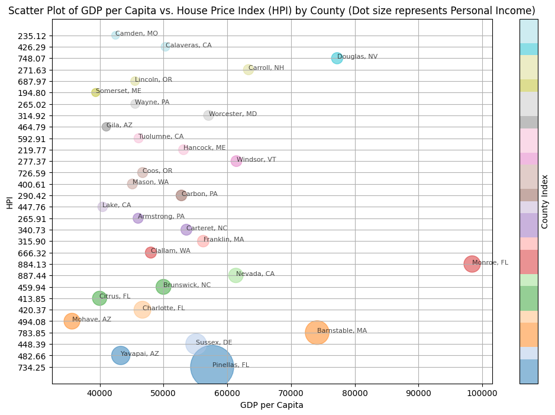

```python
import matplotlib.pyplot as plt
import pandas as pd
import traceback

def scatter_plot_and_save(dataframe, output_csv_filename):
    """
    Create a scatter plot of GDP per Capita vs. House Price Index (HPI) by county,
    annotate data points with county names, and save the DataFrame to a CSV file.

    Args:
        dataframe (pd.DataFrame): The dataset containing county data.
        output_csv_filename (str): The filename for saving the DataFrame as a CSV.

    Returns:
        pd.DataFrame: The original DataFrame.

    Raises:
        Exception: An exception is raised if there's an issue with saving the CSV.
    """

    try:
        # Create a colormap based on unique counties
        county_colors = plt.cm.get_cmap('tab20', len(dataframe))

        # Scatter plot with colored dots by county and annotated county names
        plt.figure(figsize=(12, 8))
        scatter = plt.scatter(
            dataframe['gdp_per_capita'],
            dataframe['HPI'],
            c=range(len(dataframe)),  # Use an index to assign colors
            cmap=county_colors,
            alpha=0.5,
            s=dataframe['personal_income'] / 20000  # Adjust dot size based on personal income
        )

        # Annotate data points with county names
        for i, row in dataframe.iterrows():
            plt.annotate(row['county_name'], (row['gdp_per_capita'], row['HPI']), fontsize=8, alpha=0.7)

        plt.xlabel('GDP per Capita')
        plt.ylabel('HPI')
        plt.title('Scatter Plot of GDP per Capita vs. House Price Index (HPI) by County '
                  '(Dot size represents Personal Income)')
        plt.grid(True)

        # Create a colorbar legend for counties
        cbar = plt.colorbar(scatter, label='County Index')
        cbar.set_ticks([])  # Remove numeric labels, use color only

        plt.show()

        # Save the DataFrame to a CSV file
        dataframe.to_csv(output_csv_filename, index=False)

        return dataframe

    except Exception as e:
        print(f"An error occurred: {e}")
        traceback.print_exc()
        raise e

# Example usage:
retiring_counties_really_low_working_age = scatter_plot_and_save(filtered_columns_sorted_retiring, 'scatter_plot_data.csv')
```

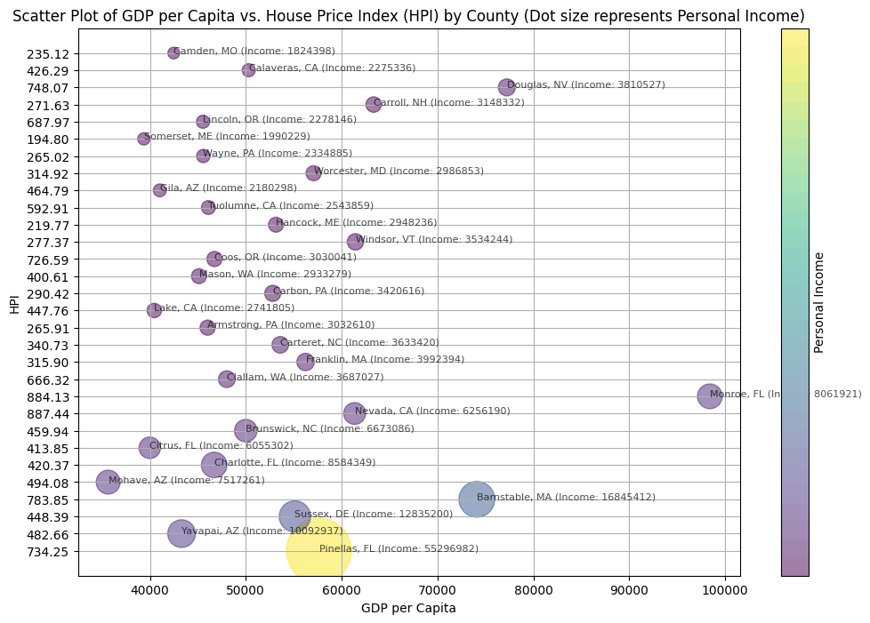

```python
import matplotlib.pyplot as plt
import pandas as pd
import traceback

def scatter_plot_and_save(dataframe, output_csv_filename):
    """
    Create a scatter plot of GDP per Capita vs. House Price Index (HPI) by county,
    annotate data points with county names and personal income, and save the DataFrame to a CSV file.

    Args:
        dataframe (pd.DataFrame): The dataset containing county data.
        output_csv_filename (str): The filename for saving the DataFrame as a CSV.

    Returns:
        pd.DataFrame: The original DataFrame.

    Raises:
        Exception: An exception is raised if there's an issue with saving the CSV.
    """

    try:
        # Create a colormap based on personal income values
        income_colors = plt.cm.get_cmap('viridis', len(dataframe))

        # Scatter plot with colored dots by personal income and annotated county names and personal income
        plt.figure(figsize=(12, 8))
        scatter = plt.scatter(
            dataframe['gdp_per_capita'],
            dataframe['HPI'],
            c=dataframe['personal_income'],  # Use personal income for color mapping
            cmap=income_colors,
            alpha=0.5,
            s=dataframe['personal_income'] / 20000  # Adjust dot size based on personal income
        )

        # Annotate data points with county names and personal income
        for i, row in dataframe.iterrows():
            plt.annotate(f"{row['county_name']} (Income: {row['personal_income']})",
                         (row['gdp_per_capita'], row['HPI']), fontsize=8, alpha=0.7)

        plt.xlabel('GDP per Capita')
        plt.ylabel('HPI')
        plt.title('Scatter Plot of GDP per Capita vs. House Price Index (HPI) by County '
                  '(Dot size represents Personal Income)')
        plt.grid(True)

        # Create a colorbar legend for personal income
        cbar = plt.colorbar(scatter, label='Personal Income', cmap=income_colors)
        cbar.set_ticks([])  # Remove numeric labels, use color only

        plt.show()

        # Save the DataFrame to a CSV file
        dataframe.to_csv(output_csv_filename, index=False)

        return dataframe

    except Exception as e:
        print(f"An error occurred: {e}")
        traceback.print_exc()
        raise e

# Example usage:
retiring_counties_really_low_working_age = scatter_plot_and_save(filtered_columns_sorted_retiring, 'scatter_plot_data.csv')
```

The dataset reveals counties with a substantial retiring population and a notable scarcity of individuals entering the working-age bracket. These findings hold financial implications that savvy investors and businesses may want to consider. With a higher proportion of residents in the retiring age group (55-64 years old), these counties could present promising opportunities for businesses offering services and amenities catering to retirees, including healthcare facilities, retirement communities, and recreational activities. However, the decreased presence of the working-age population (15-24 years old) might pose challenges for employers seeking a skilled labor force. To navigate this landscape effectively, entrepreneurs and investors can explore the potential for real estate investments, acknowledging factors like GDP per capita, personal income, and house price indices. Nevertheless, it's essential to remain mindful of market stability and growth prospects. As this demographic trend represents a long-term shift, comprehensive market research and diversification across regions and age groups are key considerations for those looking to harness these financial opportunities.

# Look at counties not retiring

```python
# Identify counties with a low proportion of individuals retiring and a high proportion of individuals entering the working age
low_retiring_high_working_age = data[(data['retiring_proportion'] < data['retiring_proportion'].quantile(0.15)) &
                                     (data['working_age_proportion'] > data['working_age_proportion'].quantile(0.85))]

# Filter the specified columns
filtered_columns = low_retiring_high_working_age[['county_name', 'Total population', 'gdp_per_capita', 'personal_income', 'total_employment', 'retiring_proportion', 'working_age_proportion','Annual Change (%)','HPI']]

# Sort the filtered data by descending population
filtered_columns_sorted = filtered_columns.sort_values(by='Total population', ascending=False)

# Display the top 10 sorted filtered data
low_retiring_high_working_age = filtered_columns_sorted.head(30)
low_retiring_high_working_age
```

|  | county_name | Total population | gdp_per_capita | personal_income | total_employment | retiring_proportion | working_age_proportion | Annual Change (%) | HPI |
| --- | --- | --- | --- | --- | --- | --- | --- | --- | --- |
| 186 | Riverside, CA | 2411439 | 43295 | 104149463 | 1,094,493 | 0.113004 | 0.143381 | 4.14 | 944.40 |
| 189 | San Bernardino, CA | 2149031 | 41253 | 89559909 | 1,074,771 | 0.112098 | 0.150959 | 4.47 | 1030.11 |
| 2266 | Bexar, TX | 1952843 | 47081 | 93739999 | 1,248,136 | 0.105322 | 0.146539 | 5.52 | 553.26 |
| 1640 | Bronx, NY | 1435068 | 37090 | 54854029 | 483,914 | 0.110016 | 0.142889 | 4.62 | 1009.01 |
| 329 | Orange, FL | 1349746 | 46649 | 66181936 | 1,167,706 | 0.111095 | 0.144216 | 5.81 | 731.44 |
| 163 | Fresno, CA | 984521 | 42987 | 43195403 | 520,083 | 0.103886 | 0.146554 | 4.61 | 743.73 |
| 168 | Kern, CA | 887641 | 39477 | 35784162 | 429,837 | 0.104168 | 0.150106 | 4.94 | 621.38 |
| 2331 | Hidalgo, TX | 855176 | 28256 | 24428598 | 393,996 | 0.082463 | 0.164544 | 3.73 | 349.06 |
| 2303 | El Paso, TX | 836062 | 37894 | 32579005 | 457,446 | 0.103190 | 0.161202 | 3.69 | 427.79 |
| 1113 | Suffolk, MA | 796605 | 83428 | 66827823 | 885,926 | 0.103253 | 0.164658 | 5.50 | 1481.67 |
| 192 | San Joaquin, CA | 742603 | 45547 | 35189770 | 345,677 | 0.111463 | 0.144127 | 4.46 | 887.79 |
| 229 | El Paso, CO | 698974 | 51015 | 36979710 | 432,504 | 0.117159 | 0.150461 | 7.29 | 820.55 |
| 2452 | Utah, UT | 605490 | 44079 | 28497337 | 373,733 | 0.066627 | 0.220673 | 7.10 | 784.84 |
| 2640 | Dane, WI | 536078 | 63668 | 35434914 | 445,517 | 0.117806 | 0.170124 | 3.77 | 685.04 |
| 207 | Tulare, CA | 461898 | 40061 | 18835476 | 212,280 | 0.098375 | 0.153447 | 4.77 | 686.66 |
| 195 | Santa Barbara, CA | 444829 | 63586 | 28509928 | 284,698 | 0.112816 | 0.194531 | 3.00 | 1423.82 |
| 1016 | East Baton Rouge, LA | 443763 | 51846 | 23650907 | 352,646 | 0.119030 | 0.176975 | 2.47 | 474.02 |
| 180 | Monterey, CA | 433410 | 56313 | 24787069 | 258,358 | 0.111077 | 0.142673 | 4.91 | 1298.11 |
| 2279 | Cameron, TX | 421666 | 30361 | 12750515 | 197,889 | 0.096840 | 0.160639 | 5.11 | 306.68 |
| 2116 | Richland, SC | 411357 | 47123 | 19535665 | 299,380 | 0.113925 | 0.194123 | 4.18 | 446.62 |
| 1195 | Washtenaw, MI | 367000 | 61447 | 22920571 | 274,917 | 0.114738 | 0.220954 | 4.27 | 635.28 |
| 2378 | Nueces, TX | 361540 | 47242 | 16689389 | 222,446 | 0.121124 | 0.143630 | 3.22 | 490.53 |
| 2265 | Bell, TX | 348574 | 43781 | 16002569 | 202,630 | 0.096267 | 0.157195 | 6.10 | 409.56 |
| 2434 | Davis, UT | 345767 | 47468 | 17050982 | 194,945 | 0.093499 | 0.144508 | 7.65 | 738.62 |
| 1725 | Cumberland, NC | 332861 | 39633 | 13264022 | 208,510 | 0.105044 | 0.172270 | 3.39 | 228.38 |
| 922 | Fayette, KY | 320601 | 52888 | 17027041 | 252,654 | 0.115212 | 0.174407 | 4.01 | 502.83 |
| 2234 | Rutherford, TN | 315815 | 43273 | 14525073 | 187,820 | 0.106730 | 0.166408 | 5.69 | 441.63 |
| 1539 | Lancaster, NE | 313158 | 51035 | 16360544 | 226,453 | 0.113553 | 0.186966 | 4.36 | 526.96 |
| 2361 | Lubbock, TX | 304808 | 45696 | 14078519 | 197,804 | 0.103659 | 0.208443 | 3.73 | 426.39 |
| 1147 | Ingham, MI | 290587 | 42183 | 12062817 | 191,110 | 0.114795 | 0.228193 | 5.24 | 398.99 |

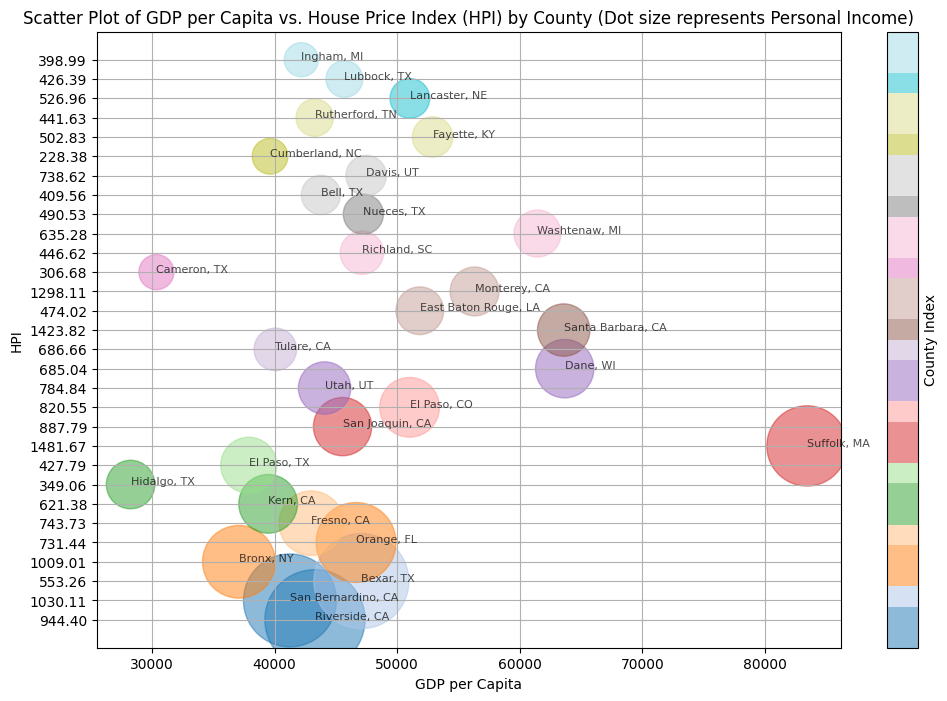

```python
import matplotlib.pyplot as plt
import pandas as pd
import traceback

def scatter_plot_and_save(dataframe, output_csv_filename):
    """
    Create a scatter plot of GDP per Capita vs. House Price Index (HPI) by county,
    annotate data points with county names, and save the DataFrame to a CSV file.

    Args:
        dataframe (pd.DataFrame): The dataset containing county data.
        output_csv_filename (str): The filename for saving the DataFrame as a CSV.

    Returns:
        pd.DataFrame: The original DataFrame.

    Raises:
        Exception: An exception is raised if there's an issue with saving the CSV.
    """

    try:
        # Create a colormap based on unique counties
        county_colors = plt.cm.get_cmap('tab20', len(dataframe))

        # Scatter plot with colored dots by county and annotated county names
        plt.figure(figsize=(12, 8))
        scatter = plt.scatter(
            dataframe['gdp_per_capita'],
            dataframe['HPI'],
            c=range(len(dataframe)),  # Use an index to assign colors
            cmap=county_colors,
            alpha=0.5,
            s=dataframe['personal_income'] / 20000  # Adjust dot size based on personal income
        )

        # Annotate data points with county names
        for i, row in dataframe.iterrows():
            plt.annotate(row['county_name'], (row['gdp_per_capita'], row['HPI']), fontsize=8, alpha=0.7)

        plt.xlabel('GDP per Capita')
        plt.ylabel('HPI')
        plt.title('Scatter Plot of GDP per Capita vs. House Price Index (HPI) by County '
                  '(Dot size represents Personal Income)')
        plt.grid(True)

        # Create a colorbar legend for counties
        cbar = plt.colorbar(scatter, label='County Index')
        cbar.set_ticks([])  # Remove numeric labels, use color only

        plt.show()

        # Save the DataFrame to a CSV file
        dataframe.to_csv(output_csv_filename, index=False)

        return dataframe

    except Exception as e:
        print(f"An error occurred: {e}")
        traceback.print_exc()
        raise e

# Example usage:
updated_dataframe = scatter_plot_and_save(low_retiring_high_working_age, 'scatter_plot_data.csv')
```

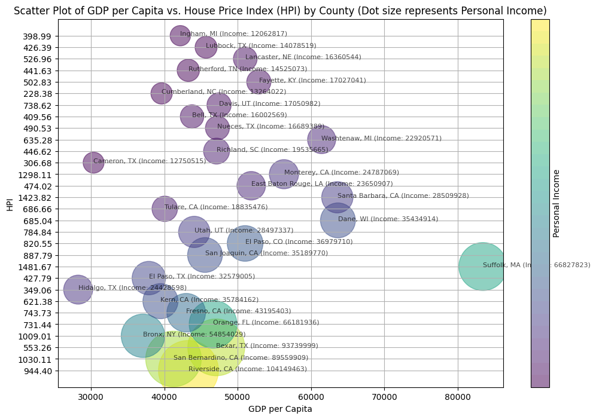

```python
import matplotlib.pyplot as plt
import pandas as pd
import traceback

def scatter_plot_and_save(dataframe, output_csv_filename):
    """
    Create a scatter plot of GDP per Capita vs. House Price Index (HPI) by county,
    annotate data points with county names and personal income, and save the DataFrame to a CSV file.

    Args:
        dataframe (pd.DataFrame): The dataset containing county data.
        output_csv_filename (str): The filename for saving the DataFrame as a CSV.

    Returns:
        pd.DataFrame: The original DataFrame.

    Raises:
        Exception: An exception is raised if there's an issue with saving the CSV.
    """

    try:
        # Create a colormap based on personal income values
        income_colors = plt.cm.get_cmap('viridis', len(dataframe))

        # Scatter plot with colored dots by personal income and annotated county names and personal income
        plt.figure(figsize=(12, 8))
        scatter = plt.scatter(
            dataframe['gdp_per_capita'],
            dataframe['HPI'],
            c=dataframe['personal_income'],  # Use personal income for color mapping
            cmap=income_colors,
            alpha=0.5,
            s=dataframe['personal_income'] / 20000  # Adjust dot size based on personal income
        )

        # Annotate data points with county names and personal income
        for i, row in dataframe.iterrows():
            plt.annotate(f"{row['county_name']} (Income: {row['personal_income']})",
                         (row['gdp_per_capita'], row['HPI']), fontsize=8, alpha=0.7)

        plt.xlabel('GDP per Capita')
        plt.ylabel('HPI')
        plt.title('Scatter Plot of GDP per Capita vs. House Price Index (HPI) by County '
                  '(Dot size represents Personal Income)')
        plt.grid(True)

        # Create a colorbar legend for personal income
        cbar = plt.colorbar(scatter, label='Personal Income', cmap=income_colors)
        cbar.set_ticks([])  # Remove numeric labels, use color only

        plt.show()

        # Save the DataFrame to a CSV file
        dataframe.to_csv(output_csv_filename, index=False)

        return dataframe

    except Exception as e:
        print(f"An error occurred: {e}")
        traceback.print_exc()
        raise e

# Example usage:
updated_dataframe = scatter_plot_and_save(low_retiring_high_working_age, 'scatter_plot_data.csv')
```

The dataset highlights counties characterized by a low proportion of individuals in the retiring age group (55-64 years old) and a high concentration of individuals entering the working-age category (15-24 years old). These findings offer valuable insights for financial planning and investment strategies. Counties with this demographic profile could represent fertile ground for businesses and industries requiring a young and dynamic workforce. Entrepreneurs and investors might consider launching ventures or expanding existing operations in these regions, focusing on sectors like technology, education, and manufacturing. Moreover, the economic indicators such as GDP per capita, personal income, and house price indices in these counties should be examined closely to assess growth potential and market stability. While these counties appear promising for businesses reliant on a robust workforce, comprehensive market research and long-term planning are essential to capitalize on these financial opportunities effectively.

# Make age distribution for the different counties. For retiring counties!

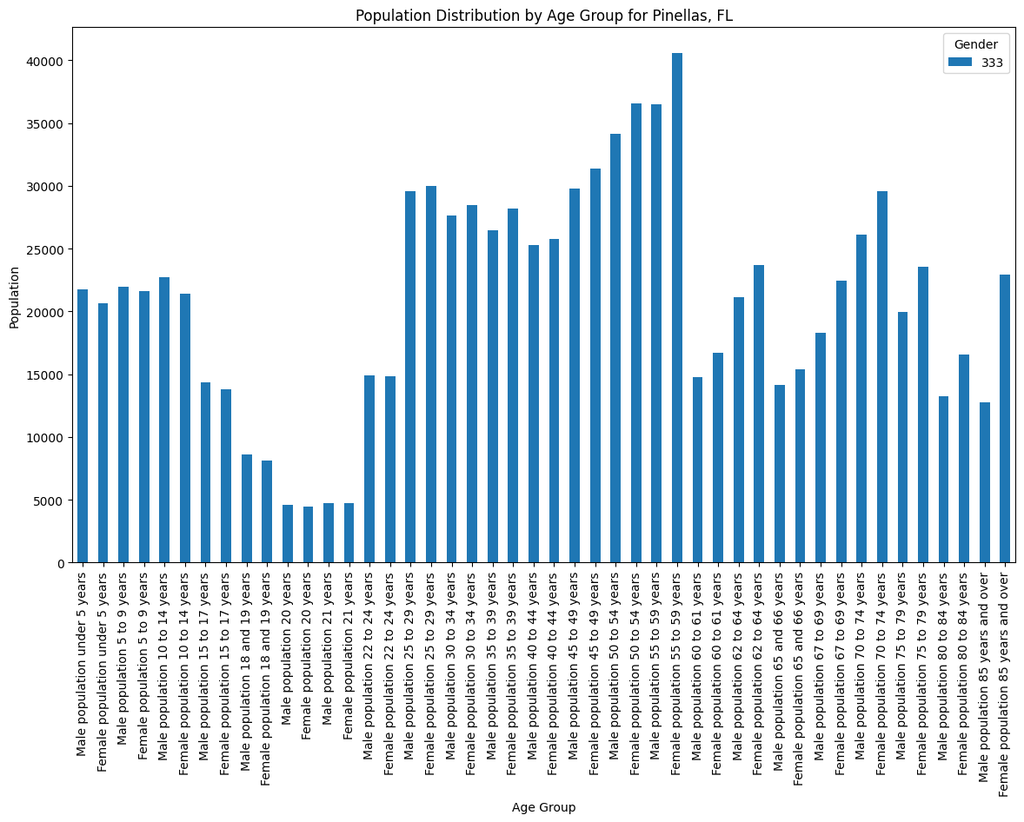

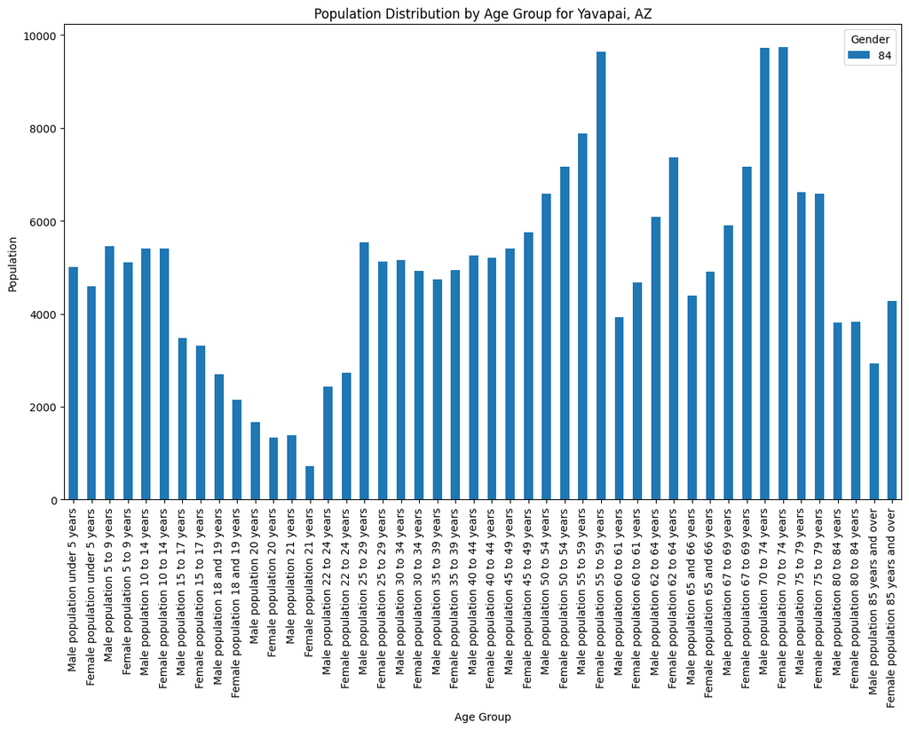

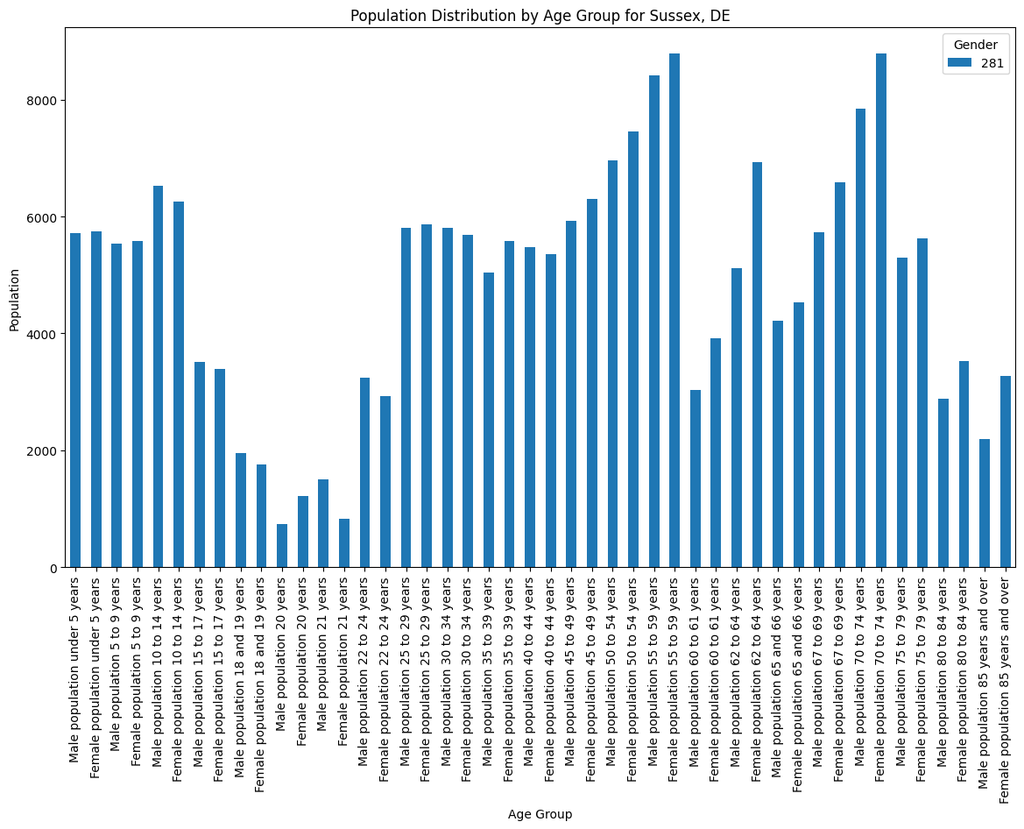

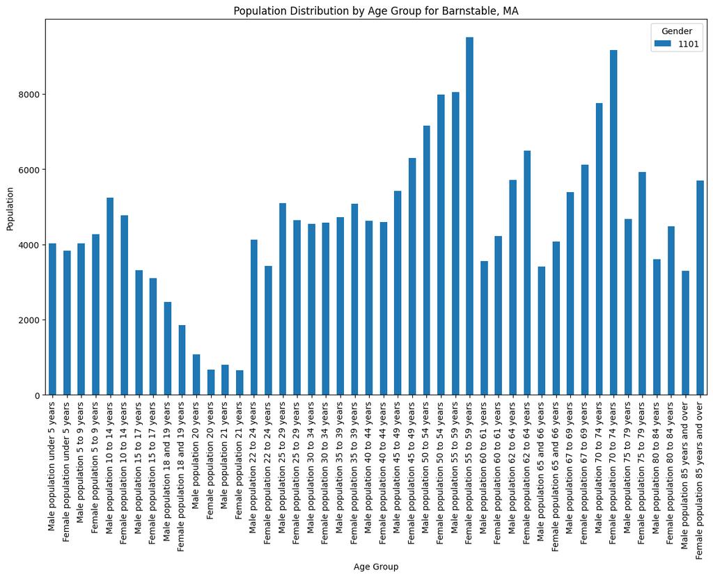

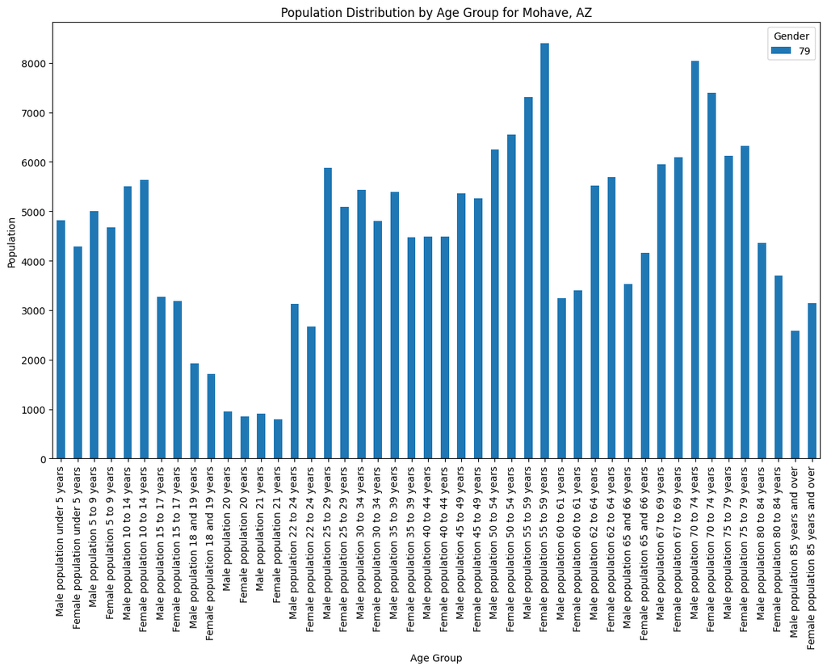

```python
import pandas as pd
import matplotlib.pyplot as plt

def filter_and_save_counties(dataset, county_names, output_csv_filename):
    """
    Filter a dataset for a list of county names, create individual stacked bar charts for age groups,
    and save the filtered dataset to a CSV file.

    Args:
        dataset (pd.DataFrame): The dataset containing county data.
        county_names (list): A list of county names to filter and analyze.
        output_csv_filename (str): The filename for saving the filtered dataset as a CSV.

    Returns:
        pd.DataFrame: The filtered dataset.

    Raises:
        Exception: An exception is raised if there's an issue with saving the CSV.
    """

    try:
        # Define age group columns
        age_group_columns = [
            'Male population under 5 years', 'Female population under 5 years',
            'Male population 5 to 9 years', 'Female population 5 to 9 years',
            'Male population 10 to 14 years', 'Female population 10 to 14 years',
            'Male population 15 to 17 years', 'Female population 15 to 17 years',
            'Male population 18 and 19 years', 'Female population 18 and 19 years',
            'Male population 20 years', 'Female population 20 years',
            'Male population 21 years', 'Female population 21 years',
            'Male population 22 to 24 years', 'Female population 22 to 24 years',
            'Male population 25 to 29 years', 'Female population 25 to 29 years',
            'Male population 30 to 34 years', 'Female population 30 to 34 years',
            'Male population 35 to 39 years', 'Female population 35 to 39 years',
            'Male population 40 to 44 years', 'Female population 40 to 44 years',
            'Male population 45 to 49 years', 'Female population 45 to 49 years',
            'Male population 50 to 54 years', 'Female population 50 to 54 years',
            'Male population 55 to 59 years', 'Female population 55 to 59 years',
            'Male population 60 to 61 years', 'Female population 60 to 61 years',
            'Male population 62 to 64 years', 'Female population 62 to 64 years',
            'Male population 65 and 66 years', 'Female population 65 and 66 years',
            'Male population 67 to 69 years', 'Female population 67 to 69 years',
            'Male population 70 to 74 years', 'Female population 70 to 74 years',
            'Male population 75 to 79 years', 'Female population 75 to 79 years',
            'Male population 80 to 84 years', 'Female population 80 to 84 years',
            'Male population 85 years and over', 'Female population 85 years and over'
        ]

        # Create an empty DataFrame to store the filtered data
        filtered_data = pd.DataFrame()

        # Loop through the county names and create individual plots
        for county_name in county_names:
            # Filter the dataset for the current county
            filtered_county_data = dataset[dataset['county_name'] == county_name]

            # Extract data for the age groups
            age_group_data = filtered_county_data[age_group_columns]

            # Transpose the data for plotting
            age_group_data = age_group_data.transpose()

            # Create a stacked bar chart for the current county
            age_group_data.plot(kind='bar', stacked=True, figsize=(14, 8))

            # Set plot title, labels, and legend
            plt.title(f'Population Distribution by Age Group for {county_name}')
            plt.xlabel('Age Group')
            plt.ylabel('Population')
            plt.legend(title='Gender')

            # Show the plot for the current county
            plt.show()

            # Append the filtered county data to the result DataFrame
            filtered_data = pd.concat([filtered_data, filtered_county_data])

        # Save the filtered dataset to a CSV file
        filtered_data.to_csv(output_csv_filename, index=False)

        return filtered_data

    except Exception as e:
        print(f"An error occurred: {e}")
        raise e

# Example usage:
county_names = [
    "Pinellas, FL",
    "Yavapai, AZ",
    "Sussex, DE",
    "Barnstable, MA",
    "Mohave, AZ"
]
filtered_dataset = filter_and_save_counties(merged_dataset, county_names, 'filtered_counties.csv')
```

# Plotting population distribution for working counties

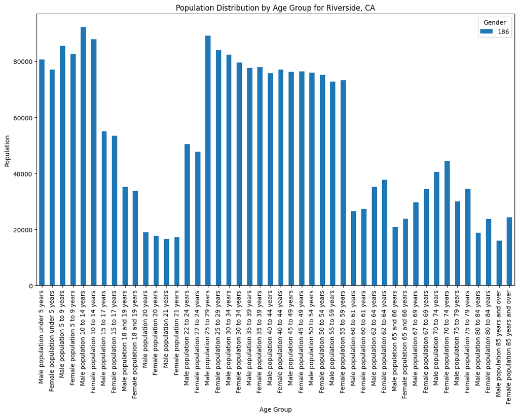

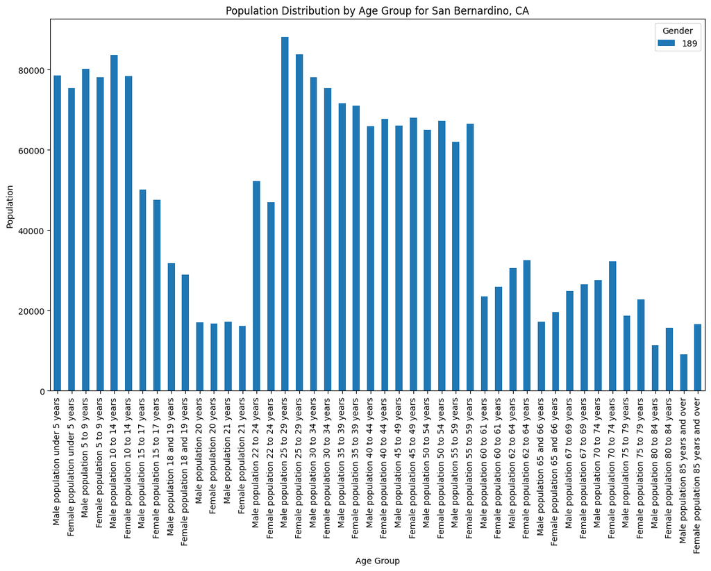

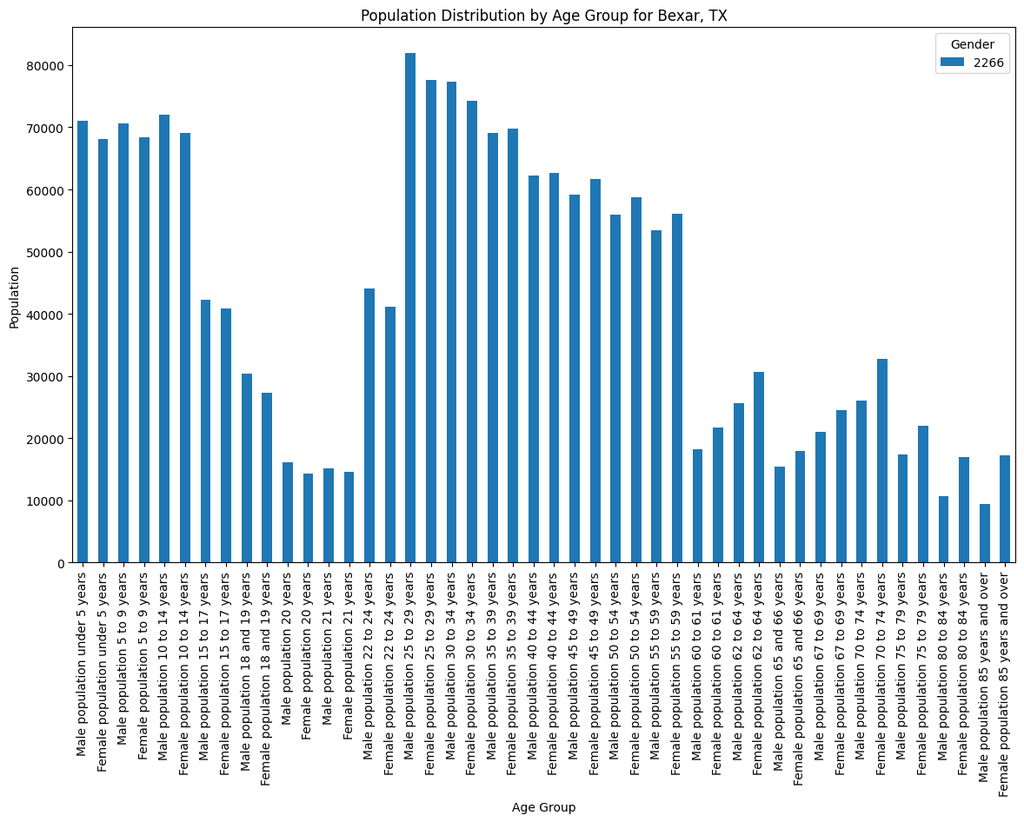

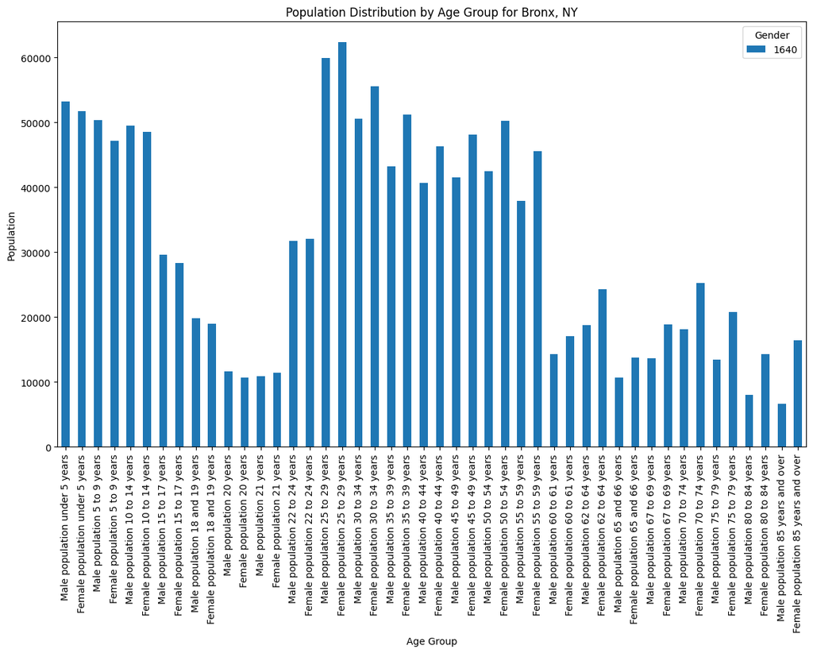

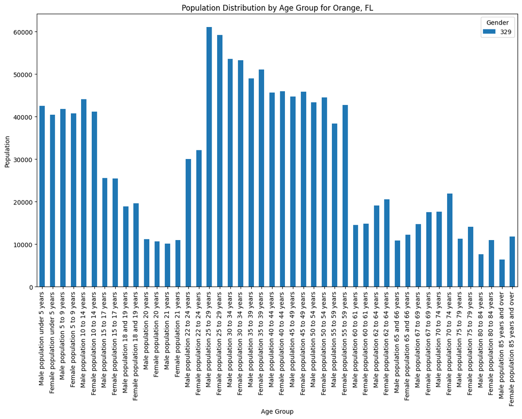

```python
county_names = [
    "Riverside, CA",
    "San Bernardino, CA",
    "Bexar, TX",
    "Bronx, NY",
    "Orange, FL"
]

filtered_dataset = filter_and_save_counties(merged_dataset, county_names, 'filtered_counties_working_counties.csv')
```

Results and Conclusion or Overview

By examining population data by age group in counties provides valuable insights into demographic trends that have wide-ranging applications. This data offers a detailed view of a county's age distribution, which is essential for businesses, policymakers, and service providers. For businesses, it helps in understanding and targeting specific age groups for products and services. Workforce assessment becomes more accurate, aiding industries reliant on particular age demographics. Moreover, it assists in economic projections, healthcare planning, education needs, retirement planning, market segmentation, policy formulation, real estate development, and infrastructure planning. This comprehensive dataset empowers various stakeholders to make informed decisions and plan effectively for the future.

Additionally, the dataset highlights two distinct demographic scenarios in counties. The first scenario, with a low proportion of retirees and a high influx of young individuals, presents opportunities for businesses requiring a dynamic workforce. Entrepreneurs and investors can consider sectors like technology, education, and manufacturing in these regions, keeping an eye on economic indicators for growth potential. The second scenario, characterized by a significant retiring population and a shortage of young workers, holds potential for businesses serving retirees. These counties may benefit from services like healthcare facilities and retirement communities. However, employers should address workforce challenges and evaluate real estate investments cautiously. In both cases, thorough market research and diversification are essential for seizing these financial opportunities effectively.